# Sorbent Activation - 2 electron transfer - Monte Carlo version 3

The concentration driving force is assumed to be at its maximum at the lean gas outlet/reduced species inlet and at 0 at the gas inlet/reduced species outlet. To a first approximation, the concentration gradient decreases linearly. The enhancement factor is calculated according to the following equations:

E = (sqrt(M) (Ei - E) / (Ei - 1)) / tanh(sqrt(M) (Ei - E) / (Ei - 1))

sqrt(M) = Hatta number = sqrt(D_co2 k2 [base]) / kL = reaction rate / mass transfer rate D_co2 = diffusion coefficient of CO2 in water, approx 0.5-2 cm2/s (using 0.5) [Wilcox book] = 0.024 exp(-2122/T), temp in K; from Versteeg and van Swaaij 1988, units cm2/s k2 = 2nd order reaction rate of CO2 + [base] kL = mass transfer coefficient, approx 0.01-0.1 cm/s

Ei = 1 + D_base [base] / (z D_co2 [CO2]_interface) = instantaneous limit D_base = diffusion coefficient of the base [CO2]_interface = concentration of CO2 at the gas-liquid interface, ie. the value from Henry’s law

For simultaneous pH swing and capture, the total enhancement factor would be 1/E_tot = 1/E_OH + 1/E_q However, since the rate constants (k2) and diffusion coefficients for the quinone are not clearly defined, use E_OH as the lower bound.

The functional form of E has the following simplified cases: sqrt(M) > 10 Ei == reaction rate is so fast it is effectively instantaneous: E = Ei sqrt(M) < 1/2 Ei == kineitically limited - pseudo first order reaction (constant CO2 concentration due to fast transport from gas) E = sqrt(M) / tanh(sqrt(M)) sqrt(M) > 3 and sqrt(M) > 1/2 Ei == strongly first order E = sqrt(M) If not true for any of these, then need to iterate to solve

```r
# Last update:
date()
```

```
[1] "Sun Sep 13 12:19:04 2020"
```

```r
# Clear work space
rm(list = ls())

# Required libraries (only need to do once)
library(dplyr) # Data frame processing
library(ggplot2)
library(patchwork) # Subplotting
library(parallel) # Pallel processing for more complicated functions with single inputs for all variables
library(doParallel); library(foreach) # Foreach loops for specific types of calculations with single inputs for only some variables
library(randomForest)
library(graphics) # Convex hull function chull
library(pracma) # Polygon area functions
library(sp) # Spatial points - used for point in polygon function
```

```r
# Explicit Functions
DIC.xA.pCO2.pH.A.k.beta = function(xA, pCO2, pH, A.tot, k1, k2, beta1, beta2){
  # Constants: carbonate and water chemistry
  kH = 3.4e-2; # M/atm
  kc1 = 10^-6.3
  kc2 = 10^-10.3
  kw = 1e-14

  # Proton concentration
  H = 10^-pH

  # Inorganic carbonate
  CO3.free = kH * pCO2 * (H^2 + kc1 * H + kc1 * kc2) / H^2

  # Bound carbon
  CO2.bound = A.tot*xA *k1*k2*(beta1*pCO2 + 2*beta2*pCO2^2)/((1 + beta1*pCO2 + beta2*pCO2^2)*k1*k2 + k1*H + H^2)

  return(CO3.free + CO2.bound)
}

pH.xA.pCO2.A.k.beta.Na = function(xA, P, At, k1, k2, beta1, beta2, Na){
  # Constants: carbonate and water chemistry
  kH = 3.4e-2; # M/atm
  kc1 = 10^-6.3
  kc2 = 10^-10.3
  kw = 1e-14

  # Polynomial root
  x5 = 1
  x4 = k1 + Na + 2*At*xA
  x3 = k1*k2 - kw + k1*Na + beta1*k1*k2*P - kc1*kH*P +
      beta2*k1*k2*P^2 + 2*At*k1*xA - 2*At*k2*xA
  x2 = (-k1)*kw + k1*k2*Na - k1*kc1*kH*P - 2*kc1*kc2*kH*P + beta1*k1*k2*Na*P + beta2*k1*k2*Na*P^2 -
      2*At*k1*k2*xA + 2*At*beta1*k1*k2*P*xA + 2*At*beta2*k1*k2*P^2*xA
  x1 = (-k1)*k2*kw - k1*k2*kc1*kH*P - 2*k1*kc1*kc2*kH*P - beta1*k1*k2*kw*P -
      beta1*k1*k2*kc1*kH*P^2 - beta2*k1*k2*kw*P^2 - beta2*k1*k2*kc1*kH*P^3
  x0 = - 2*k1*k2*kc1*kc2*kH*P - 2*beta1*k1*k2*kc1*kc2*kH*P^2 -
     2*beta2*k1*k2*kc1*kc2*kH*P^3
  roots = polyroot(c(x0, x1, x2, x3, x4, x5))

  # Only the real and positive roots
  H = roots[abs(Im(roots)) < 1e-8]
  H = Re(H[Re(H) > 0])

  # It is possible for multiple roots to satisfy the solution. Typical pH is going to be the one closest to 7-8
  # H = H[which.min(abs(-log10(H) - 7))]

  return(-log10(H[1]))
}


pCO2.xA.pH.A.k.beta.Na = function(xA, pH, At, k1, k2, beta1, beta2, Na, pCO2.prev){
  # Constants: carbonate and water chemistry
  kH = 3.4e-2; # M/atm
  kc1 = 10^-6.3
  kc2 = 10^-10.3
  kw = 1e-14
  # Proton concentration
  H = 10^-pH

  # Polynomial root
  x3 = (-beta2)*H*k1*k2*kc1*kH - 2*beta2*k1*k2*kc1*kc2*kH
  x2 = beta2*H^3*k1*k2 - beta1*H*k1*k2*kc1*kH - 2*beta1*k1*k2*kc1*kc2*kH -
      beta2*H*k1*k2*kw + beta2*H^2*k1*k2*Na + 2*At*beta2*H^2*k1*k2*xA
  x1 = beta1*H^3*k1*k2 - H^3*kc1*kH - H^2*k1*kc1*kH - H*k1*k2*kc1*kH - 2*H^2*kc1*kc2*kH - 2*H*k1*kc1*kc2*kH -
      2*k1*k2*kc1*kc2*kH - beta1*H*k1*k2*kw + beta1*H^2*k1*k2*Na +
      2*At*beta1*H^2*k1*k2*xA
  x0 = H^5 + H^4*k1 + H^3*k1*k2 - H^3*kw - H^2*k1*kw - H*k1*k2*kw +
      H^4*Na + H^3*k1*Na + H^2*k1*k2*Na + 2*At*H^4*xA + 2*At*H^3*k1*xA -
      2*At*H^3*k2*xA - 2*At*H^2*k1*k2*xA
  roots = polyroot(c(x0, x1, x2, x3))

  # Only the real and positive roots
  pCO2 = roots[abs(Im(roots)) < 1e-8]
  pCO2 = Re(pCO2[Re(pCO2) > 0])
  # There are cases of multiepl roots. Find the one that is closest to the previous known value
  pCO2 = pCO2[which.min(abs(log10(pCO2) - log10(pCO2.prev)))]

  return(pCO2)
}

pH.DIC.xA.pCO2.A.k.beta = function(DIC, xA, P, At, k1, k2, beta1, beta2){
  # Constants: carbonate and water chemistry
  kH = 3.4e-2; # M/atm
  kc1 = 10^-6.3
  kc2 = 10^-10.3
  kw = 1e-14

  # Polynomial root
  x4 = (DIC - kH*P)
  x3 = (DIC*k1 - k1*kH*P - kc1*kH*P)
  x2 = (DIC*k1*k2 + beta1*DIC*k1*k2*P - k1*k2*kH*P - k1*kc1*kH*P - kc1*kc2*kH*P + beta2*DIC*k1*k2*P^2 -
    beta1*k1*k2*kH*P^2 - beta2*k1*k2*kH*P^3 - At*beta1*k1*k2*P*xA - 2*At*beta2*k1*k2*P^2*xA)
  x1 = ((-k1)*k2*kc1*kH*P - k1*kc1*kc2*kH*P - beta1*k1*k2*kc1*kH*P^2 -
        beta2*k1*k2*kc1*kH*P^3)
  x0 = (-k1)*k2*kc1*kc2*kH*P - beta1*k1*k2*kc1*kc2*kH*P^2 - beta2*k1*k2*kc1*kc2*kH*P^3
  roots = polyroot(c(x0, x1, x2, x3, x4))

  # Only the real and positive roots
  H = roots[abs(Im(roots)) < 1e-8]
  H = Re(H[Re(H) > 0])
  return(-log10(H))
}

pCO2.DIC.xA.pH.A.k.beta = function(DIC, xA, pH, At, k1, k2, beta1, beta2){
  # Constants: carbonate and water chemistry
  kH = 3.4e-2; # M/atm
  kc1 = 10^-6.3
  kc2 = 10^-10.3
  kw = 1e-14

  H = 10^-pH

  # Polynomial root
  x3 = ((-beta2)*H^2*k1*k2*kH - beta2*H*k1*k2*kc1*kH - beta2*k1*k2*kc1*kc2*kH)
  x2 = (beta2*DIC*H^2*k1*k2 - beta1*H^2*k1*k2*kH - beta1*H*k1*k2*kc1*kH -
        beta1*k1*k2*kc1*kc2*kH - 2*At*beta2*H^2*k1*k2*xA)
  x1 = (beta1*DIC*H^2*k1*k2 - H^4*kH - H^3*k1*kH - H^2*k1*k2*kH - H^3*kc1*kH -
        H^2*k1*kc1*kH - H*k1*k2*kc1*kH - H^2*kc1*kc2*kH - H*k1*kc1*kc2*kH -
        k1*k2*kc1*kc2*kH - At*beta1*H^2*k1*k2*xA)
  x0 = DIC*H^4 + DIC*H^3*k1 + DIC*H^2*k1*k2
  roots = polyroot(c(x0, x1, x2, x3))

  # Only the real and positive roots
  pCO2 = roots[abs(Im(roots)) < 1e-8]
  pCO2 = Re(pCO2[Re(pCO2) > 0])
  return(pCO2)
}

pH.it.guess.DIC.At.k.beta = function(pH.guess, xA.next, DIC, A.tot, k1, k2, beta1, beta2, Na){
  # Iterates to solve the pH and pCO2 at the next electrochemical time step,
  # given xA and DIC and an initial guess (the pH at the previous time step)
  pCO2.it = c(); pH.it = c(pH.guess)
  pCO2.it = pCO2.DIC.xA.pH.A.k.beta(DIC = DIC, xA = xA.next, pH = pH.it, At = A.tot, k1 = k1, k2 = k2, beta1 = beta1, beta2 = beta2)
  for(n in 2:74){
    pH.it[n] = pH.xA.pCO2.A.k.beta.Na(xA = xA.next, P = pCO2.it[n - 1], At = A.tot, k1 = k1, k2 = k2, beta1 = beta1, beta2 = beta2, Na = Na)
    pCO2.it[n] = pCO2.DIC.xA.pH.A.k.beta(DIC = DIC, xA = xA.next, pH = pH.it[n], At = A.tot, k1 = k1, k2 = k2, beta1 = beta1, beta2 = beta2)
  }
  n = 75
  pH.it[n] = pH.xA.pCO2.A.k.beta.Na(xA = xA.next, P = pCO2.it[n - 1], At = A.tot, k1 = k1, k2 = k2, beta1 = beta1, beta2 = beta2, Na = Na)
  # Due to some oscillatory instabilities under specific conditions, take the last 25 and use the value that is closest to the guess
  pH.res = pH.it[50:75]
  pH.res = pH.res[which.min(abs(pH.res) - pH.guess)]
  return(pH.res)
}
```

```r
# Derived functions
# DIC difference: CO2/L*cycle
DIC.diff = function(Na, A, beta1, beta2, k1, k2, pCO2.in, pCO2.out){
  # Constants
  xA.lim = c(0.025, 0.975)
  # pCO2.in = 0.1; pCO2.out = 1

  # Absorption: low P, high xA
  start.soln = data.frame(p.CO2 = pCO2.in, xA = max(xA.lim))
  start.soln$pH = pH.xA.pCO2.A.k.beta.Na(xA = start.soln$xA, P = start.soln$p.CO2,
                                     At = A, k1 = k1, k2 = k2, beta1 = beta1, beta2 = beta2, Na = Na)
  start.soln$DIC = DIC.xA.pCO2.pH.A.k.beta(xA = start.soln$xA, pCO2 = start.soln$p.CO2, pH = start.soln$pH,
                                       A.tot = A, k1 = k1, k2 = k2, beta1 = beta1, beta2 = beta2)

  # Desorption: high P, low xA
  stop.soln = data.frame(p.CO2 = pCO2.out, xA = min(xA.lim))
  stop.soln$pH = pH.xA.pCO2.A.k.beta.Na(xA = stop.soln$xA, P = stop.soln$p.CO2,
                                     At = A, k1 = k1, k2 = k2, beta1 = beta1, beta2 = beta2, Na = Na)
  stop.soln$DIC = DIC.xA.pCO2.pH.A.k.beta(xA = stop.soln$xA, pCO2 = stop.soln$p.CO2, pH = stop.soln$pH,
                                       A.tot = A, k1 = k1, k2 = k2, beta1 = beta1, beta2 = beta2)

  # Calculate the difference
  DIC.diff = start.soln$DIC - stop.soln$DIC
  return(DIC.diff)
}

# Minimum partial pressure of the lean gas
pCO2.lean = function(Na, A, beta1, beta2, k1, k2, pCO2.out){
  # Constants
  xA.lim = c(0.025, 0.975)

  # Calculate the DIC of the outlet after complete desorption: high P, low xA
  stop.soln = data.frame(p.CO2 = pCO2.out, xA = min(xA.lim))
  stop.soln$pH = pH.xA.pCO2.A.k.beta.Na(xA = stop.soln$xA, P = stop.soln$p.CO2,
                                     At = A, k1 = k1, k2 = k2, beta1 = beta1, beta2 = beta2, Na = Na)
  stop.soln$DIC = DIC.xA.pCO2.pH.A.k.beta(xA = stop.soln$xA, pCO2 = stop.soln$p.CO2, pH = stop.soln$pH,
                                       A.tot = A, k1 = k1, k2 = k2, beta1 = beta1, beta2 = beta2)

  # Calculate the pCO2 when fully reduced, holding DIC constant. Due to the need for a previous case, run in ~5 steps
  out.soln = data.frame(DIC = stop.soln$DIC, xA = seq(from = min(xA.lim), to = max(xA.lim), length.out = 5))
  # Loop the pH and pCO2 simultaneously
  loop.pH = pH.it.guess.DIC.At.k.beta(pH.guess = stop.soln$pH[1], xA.next = out.soln$xA[1], DIC = out.soln$DIC[1],
                                      A.tot = A, k1 = k1, k2 = k2, beta1 = beta1, beta2 = beta2, Na = Na)
  loop.pCO2 = pCO2.xA.pH.A.k.beta.Na(xA = out.soln$xA[1], pH = loop.pH[1],
                                     At = A, k1 = k1, k2 = k2, beta1 = beta1, beta2 = beta2, Na = Na, pCO2.prev = stop.soln$p.CO2)
  for(i in 2:5){
    loop.pH[i] = pH.it.guess.DIC.At.k.beta(pH.guess = loop.pH[i-1], xA.next = out.soln$xA[i], DIC = out.soln$DIC[i],
                                        A.tot = A, k1 = k1, k2 = k2, beta1 = beta1, beta2 = beta2, Na = Na)
    loop.pCO2[i] = pCO2.xA.pH.A.k.beta.Na(xA = out.soln$xA[i], pH = loop.pH[i],
                                       At = A, k1 = k1, k2 = k2, beta1 = beta1, beta2 = beta2, Na = Na, pCO2.prev = loop.pCO2[i-1])

  }
  return(loop.pCO2[i])
}

# Total energy demand - separated process for simplicity
Energy.tot = function(k1, k2, beta1, beta2, A.tot, Na, pCO2.in, pCO2.out){
  # Constants
  z = 2; R = 8.314; T = 298; F = 96485; resolution = 151;
  # pCO2.in = 0.1; pCO2.out = 1
  xA.lim = c(0.025, 0.975)

  # 1 -> 2: Electrochemical oxidation (xA decrease to endpoint), constant DIC
  # Starting solution for initial guess: low P, high xA
  start.soln = data.frame(p.CO2 = pCO2.in, xA = max(xA.lim))
  start.soln$pH = pH.xA.pCO2.A.k.beta.Na(xA = start.soln$xA, P = start.soln$p.CO2,
                                       At = A.tot, k1 = k1, k2 = k2, beta1 = beta1, beta2 = beta2, Na = Na)
  start.soln$DIC = DIC.xA.pCO2.pH.A.k.beta(xA = start.soln$xA, pCO2 = start.soln$p.CO2, pH = start.soln$pH,
                                         A.tot = A.tot, k1 = k1, k2 = k2, beta1 = beta1, beta2 = beta2)
  # Anode progress
  E.anode = data.frame(DIC = start.soln$DIC, xA = seq(from = start.soln$xA[1], to = min(xA.lim), length.out = resolution))
  # Loop to solve the ieration function
  loop = pH.it.guess.DIC.At.k.beta(pH.guess = start.soln$pH[1], xA.next = E.anode$xA[1], DIC = E.anode$DIC[1],
                                       A.tot = A.tot, k1 = k1, k2 = k2, beta1 = beta1, beta2 = beta2, Na = Na)
  for(i in 2:length(E.anode$DIC)){
    loop = c(loop, pH.it.guess.DIC.At.k.beta(pH.guess = loop[i-1], xA.next = E.anode$xA[i], DIC = E.anode$DIC[i],
                                         A.tot = A.tot, k1 = k1, k2 = k2, beta1 = beta1, beta2 = beta2, Na = Na))
  }
  # Some iterations don't converge completely, leading to single points that deviated from the rest of the curve. This is characterized by a single point that is a local maxima or minimum. Endpoints are asusmed to be good
  loop.check.left = loop[1:(resolution-2)] - loop[2:(resolution-1)]
  loop.check.right = loop[2:(resolution-1)] - loop[3:(resolution)]
  # If the signs are different, then it is a local shift
  loop.pos = c(TRUE, (sign(loop.check.left) == sign(loop.check.right)), TRUE)
  for(pos in which(loop.pos == FALSE)){ # Take the average
    loop[pos] = (loop[pos-1] + loop[pos+1])/2
  }
  E.anode$pH = loop;
  # Loop pCO2 calculation as well, since the pCO2 function relies on the previous point
  loop = pCO2.xA.pH.A.k.beta.Na(xA = E.anode$xA[1], pH = E.anode$pH[1],
                                At = A.tot, k1 = k1, k2 = k2, beta1 = beta1, beta2 = beta2, Na = Na, pCO2.prev = start.soln$p.CO2)
  for(i in 2:length(E.anode$DIC)){
    loop[i] = pCO2.xA.pH.A.k.beta.Na(xA = E.anode$xA[i], pH = E.anode$pH[i],
                                  At = A.tot, k1 = k1, k2 = k2, beta1 = beta1, beta2 = beta2, Na = Na, pCO2.prev = loop[i-1])
  }
  E.anode$p.CO2 = loop
  E.anode$q = abs(E.anode$xA - E.anode$xA[1])*A.tot*z*F # Coulombs

  # 3 -> 4: Electrochemical reduction (xA increase to endpoint), constant DIC
  # Starting solution for initial guess: high P, low xA
  stop.soln = data.frame(p.CO2 = pCO2.out, xA = min(xA.lim))
  stop.soln$pH = pH.xA.pCO2.A.k.beta.Na(xA = stop.soln$xA, P = stop.soln$p.CO2,
                                       At = A.tot, k1 = k1, k2 = k2, beta1 = beta1, beta2 = beta2, Na = Na)
  stop.soln$DIC = DIC.xA.pCO2.pH.A.k.beta(xA = stop.soln$xA, pCO2 = stop.soln$p.CO2, pH = stop.soln$pH,
                                         A.tot = A.tot, k1 = k1, k2 = k2, beta1 = beta1, beta2 = beta2)
  # Cathode progress
  E.cathode = data.frame(DIC = stop.soln$DIC[1], xA = seq(from = stop.soln$xA[1], to = max(xA.lim), length.out = resolution))
  # Loop to solve the ieration function
  loop = pH.it.guess.DIC.At.k.beta(pH.guess = stop.soln$pH[1], xA.next = E.cathode$xA[1], DIC = E.cathode$DIC[1],
                                       A.tot = A.tot, k1 = k1, k2 = k2, beta1 = beta1, beta2 = beta2, Na = Na)
  for(i in 2:length(E.cathode$DIC)){
    loop = c(loop, pH.it.guess.DIC.At.k.beta(pH.guess = loop[i-1], xA.next = E.cathode$xA[i], DIC = E.cathode$DIC[i],
                                         A.tot = A.tot, k1 = k1, k2 = k2, beta1 = beta1, beta2 = beta2, Na = Na))
  }
  # Some iterations don't converge completely, leading to single points that deviated from the rest of the curve. This is characterized by a single point that is a local maxima or minimum. Endpoints are asusmed to be good
  loop.check.left = loop[1:(resolution-2)] - loop[2:(resolution-1)]
  loop.check.right = loop[2:(resolution-1)] - loop[3:(resolution)]
  # If the signs are different, then it is a local shift
  loop.pos = c(TRUE, (sign(loop.check.left) == sign(loop.check.right)), TRUE)
  for(pos in which(loop.pos == FALSE)){ # Take the average
    loop[pos] = (loop[pos-1] + loop[pos+1])/2
  }
  E.cathode$pH = loop;
  # Loop pCO2 calculation as well, since the pCO2 function relies on the previous point
  loop = pCO2.xA.pH.A.k.beta.Na(xA = E.cathode$xA[1], pH = E.cathode$pH[1],
                                At = A.tot, k1 = k1, k2 = k2, beta1 = beta1, beta2 = beta2, Na = Na, pCO2.prev = stop.soln$p.CO2)
  for(i in 2:length(E.cathode$DIC)){
    loop[i] = pCO2.xA.pH.A.k.beta.Na(xA = E.cathode$xA[i], pH = E.cathode$pH[i],
                                  At = A.tot, k1 = k1, k2 = k2, beta1 = beta1, beta2 = beta2, Na = Na, pCO2.prev = loop[i-1])
  }
  E.cathode$p.CO2 = loop
  E.cathode$q = abs(E.cathode$xA - E.cathode$xA[1])*A.tot*z*F # Coulombs

  # Equilibrium potential: Deviation from standard reduction potential
  E.anode$H = 10^-E.anode$pH
  E.anode$E = R*T/(z*F) * log( (1 - E.anode$xA)/E.anode$xA *
                                   ((1 + beta1*E.anode$p.CO2 + beta2*E.anode$p.CO2^2)*k1*k2 + k1*E.anode$H + E.anode$H^2)/(k1*k2))
  E.cathode$H = 10^-E.cathode$pH
  E.cathode$E = R*T/(z*F) * log( (1 - E.cathode$xA)/E.cathode$xA *
                                   ((1 + beta1*E.cathode$p.CO2 + beta2*E.cathode$p.CO2^2)*k1*k2 + k1*E.cathode$H + E.cathode$H^2)/(k1*k2))

  # Total energy
  E.cell = data.frame(q = E.anode$q, V = E.anode$E - E.cathode$E)
  # Only the positive energy demand
  E.cell = filter(E.cell, V > 0)
  len = length(E.cell$q)
  if(len == 0){
    E.cell = data.frame(q = rep(x = 0, times = 10), V = rep(x = 0, times = 10))
    len = 10
  }
  # E.anode$typ = "anode"; E.cathode$typ = "cathode"
  Energy.tot.sep = sum(0.5*(E.cell$V[2:len] + E.cell$V[1:(len-1)])*(E.cell$q[2:len] - E.cell$q[1:(len-1)]))
  return(Energy.tot.sep)
}
```

```r
# Create a function to set up the initial set randomly in the space given a beta2
boundary.setup = function(beta2){
  ## Set up the parameter space
  A.range = c(0.1, 1, 2) # 3 values: the minimum, the median, and the maximum
  Na.shift.range = c(-0.1, 0, 0.1)
  k1.range = 10^-seq(from = 4, to = 12, length.out = 3); pka1.bound = -log10(k1.range)
  k2.range = 10^-seq(from = 4, to = 14, length.out = 3); pka2.bound = -log10(k2.range)
  if(beta2 == 0){
    # Grid
    combinations = expand.grid(Na.shift.range, A.range, k1.range, k2.range)
    names(combinations) = c("Na.shift", "A", "k1", "k2")
    # Minimum length is based on the number of variables. If beta2 = 0, then there are only 4. Otherwise 5.
    num.var = 4
    set.len = ceiling( (3^num.var) /100)*100
    combinations$beta1 = 0
  } else{
    beta1.range = c(0, 10^c(log10(beta2)/2, log10(beta2)))
    # Grid
    combinations = expand.grid(Na.shift.range, A.range, k1.range, k2.range, beta1.range)
    names(combinations) = c("Na.shift", "A", "k1", "k2", "beta1")
    # Minimum length is based on the number of variables. If beta2 = 0, then there are only 4. Otherwise 5.
    num.var = 5
    set.len = ceiling( (3^num.var) /100)*100
  }
  # Sodium concentration is shift from the Na = 0 at min(xA) (when xA = 0.025). Since Na is defined as when xA = 0, then it is shifted slightly
  combinations$Na = (combinations$Na.shift-0.025*0.5)*combinations$A
  # Apply constraint: pka2 > pka1. Adjusted by ~0.3 pH units
  combinations$k2[combinations$k2 >= combinations$k1] = combinations$k1[combinations$k2 >= combinations$k1]*0.5
  # Save the samples
  boundary.case = combinations

  ## Include more points until a set number based on the number of variables
  len = set.len - length(combinations$A)
  if(beta2 == 0){
    combinations = data.frame(A = runif(n = len, min = min(A.range), max = max(A.range)),
                          Na.shift = runif(n = len, min = min(Na.shift.range), max = max(Na.shift.range)),
                          k1 = 10^-runif(n = len, min = min(pka1.bound)-0.25, max = max(pka1.bound)+0.25),
                          k2 = 10^-runif(n = len, min = min(pka2.bound)-0.25, max = max(pka2.bound)+0.25),
                          beta1 = 0)
  } else{
    combinations = data.frame(A = runif(n = len, min = min(A.range), max = max(A.range)),
                          Na.shift = runif(n = len, min = min(Na.shift.range), max = max(Na.shift.range)),
                          k1 = 10^-runif(n = len, min = min(pka1.bound)-0.25, max = max(pka1.bound)+0.25),
                          k2 = 10^-runif(n = len, min = min(pka2.bound)-0.25, max = max(pka2.bound)+0.25),
                          beta1 = runif(n = len, min = min(beta1.range), max = max(beta1.range)))
  }
  combinations$Na = (combinations$Na.shift-0.025*0.5)*combinations$A
  # Apply constraint of pka2 > pka1. For points that don't satisfy this, make pka2 between 0.1 and 1 pH unit greater than pka1
  len = length(which(combinations$k2 >= combinations$k1))
  combinations$k2[combinations$k2 >= combinations$k1] = combinations$k1[combinations$k2 >= combinations$k1]*10^-runif(n = len, min = 0.1, max = 1)
  # Add the samples
  boundary.case = rbind(boundary.case, combinations)

  # Add iteration number and beta2
  boundary.case$beta2 = beta2; boundary.case$it.num = 0
  return(boundary.case)
}
# Run test of algorithm with beta2 = 0
boundary.case = boundary.setup(beta2 = 0)

# Run the DIC and energy demand on this set of inputs. Use best case flue gas conditions. Only interested in the separate case, for the simplicity of testing the method
boundary.case$DIC.diff = mcmapply(DIC.diff, Na = boundary.case$Na, A =  boundary.case$A, beta1 = boundary.case$beta1, beta2 = boundary.case$beta2,
                                  k1 = boundary.case$k1, k2 = boundary.case$k2, pCO2.in = 0.15, pCO2.out = 1)
boundary.case$pCO2.lean = mcmapply(pCO2.lean, Na = boundary.case$Na, A =  boundary.case$A, beta1 = boundary.case$beta1, beta2 = boundary.case$beta2,
                                  k1 = boundary.case$k1, k2 = boundary.case$k2, pCO2.out = 1)
Energy.J.L = mcmapply(Energy.tot, k1 = boundary.case$k1, k2 = boundary.case$k2,
           beta1 = boundary.case$beta1, beta2 = boundary.case$beta2,
           A.tot = boundary.case$A, Na = boundary.case$Na,
           pCO2.in = 0.15, pCO2.out = 1, mc.cores = 2)
# Energy.J.L
boundary.case$Energy.sep = Energy.J.L/boundary.case$DIC.diff*1e-3
var = c("Na.shift", "A", "k1", "k2", "beta1", "Na", "beta2", "it.num", "DIC.diff", "pCO2.lean", "Energy.sep")
boundary.case = boundary.case[var] # Eliminate metadata from the function calls
```

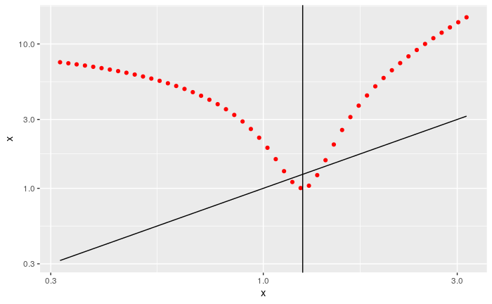

```r
# Functions: Kinetics
# Check the plot of the enhancement factor
Ha = 2
Ei = 1.25
x = 10^seq(from = -0.5, to = 0.5, length.out = 50)
y = (Ha*(Ei - x) / (Ei - 1)) / tanh(Ha*(Ei - x) / (Ei - 1))
ggplot(data.frame(x, y)) +
  geom_path(mapping = aes(x = x, y = x)) +  geom_point(mapping = aes(x = x, y = y), color = "red") +
  scale_x_log10() + scale_y_log10() +
  geom_vline(xintercept = Ei)
```

```r
# Roughly linear fit to solve the root?
x.guess = c(1.05, 1.1)*Ei
y.guess = (Ha*(Ei - x.guess) / (Ei - 1)) / tanh(Ha*(Ei - x.guess) / (Ei - 1)) - x.guess
slp.fit = (y.guess[1] - y.guess[2]) / (x.guess[1] - x.guess[2])
y.fit = slp.fit*(x - x.guess[1]) + y.guess[1]
-y.guess[1]/slp.fit + x.guess[1]
```

```
[1] 1.397976
```

```r
x.guess = c(0.9, 0.95)*Ei
y.guess = (Ha*(Ei - x.guess) / (Ei - 1)) / tanh(Ha*(Ei - x.guess) / (Ei - 1)) - x.guess
slp.fit = (y.guess[1] - y.guess[2]) / (x.guess[1] - x.guess[2])
y.fit2 = slp.fit*(x - x.guess[1]) + y.guess[1]
-y.guess[1]/slp.fit + x.guess[1]
```

```
[1] 1.165034
```

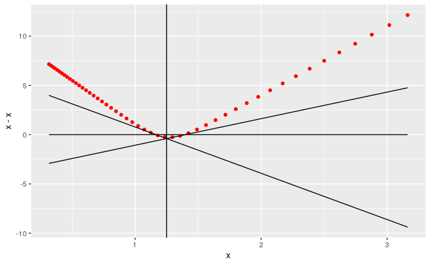

```r
# There are 2 roots - use the lower of the two; Ei is the upper limit
ggplot(data.frame(x, y, y.fit, y.fit2)) +
  geom_path(mapping = aes(x = x, y = x-x)) +  geom_point(mapping = aes(x = x, y = y-x), color = "red") +
  geom_path(mapping = aes(x = x, y = y.fit)) +
  geom_path(mapping = aes(x = x, y = y.fit2)) +
  # scale_x_log10() + scale_y_log10() +
  geom_vline(xintercept = Ei)
```

```r
# Clear variables
rm(x.guess, y.guess, slp.fit, y.fit2, y.fit, Ei, Ha, x, y)

# Since I am solving the reporting the best case-scenario for the energy, it makes more sense to report peak flux.

Enhance.factor = function(pH, pCO2.in, A, k1, k2, beta1, beta2, pCO2){
  # Constants: general
  kw = 1e-14 # M^2
  kH = 3.4e-2; # M/atm
  z = 1 # OH- + CO2 = HCO3-
  # Constants: from Wilcox 2012
  Dco2 = 0.5e-5 # cm2/s, assume slowest due to high ionic strength
  kL = 0.1 # Assume fast mass transfer of typical range
  # Constants: average of Pocker 1997, Zeman 2007, Stolaroff 2008, Wilcox 2012
  k.rate = (6.03e3 + 6.745e3 + 8.5e3 + 12.1e3)/4
  # Constants: Lvov2012
  Doh = 5.2e-5 # cm2/s

  # Base concentration = OH + HQ- + 2Q--
  H = 10^-pH
  OH = kw/H
  base = OH + A*(2*k1*k2 + H*k1) / (H^2 + H*k1 + k1*k2*(1 + beta1*pCO2 + beta2*pCO2^2))

  # Interface CO2 concentration - assume 90% capture from the inlet
  CO2.int = 0.1*pCO2.in*kH

  # Hatta number: reaction rate / mass transfer rate
  Ha = sqrt(Dco2*base*k.rate)/kL
  # Instantaneous enhancement factor
  Ei = 1 + Doh*base / (z*Dco2*CO2.int)

  # return(c(Ei, Ha / tanh(Ha), Ha))
  # Check the extreme cases for E to simplify the equations
  if(Ha > 10*Ei){ # Instantaneous
    E = Ei
  } else if(Ha < Ei/2){ # Pseudo-1st order
    E = Ha / tanh(Ha)
  } else if(Ha > 3){ # 1st order
    E = Ha
  } else{ # No simplification - Solve the root that is less than Ei, as Ei is the upper bound
    x.guess = c(0.9, 0.95)*Ei
    for(i in 1:5){ # Newton's method
      y.guess = (Ha*(Ei - x.guess) / (Ei - 1)) / tanh(Ha*(Ei - x.guess) / (Ei - 1)) - x.guess
      slp.fit = (y.guess[1] - y.guess[2]) / (x.guess[1] - x.guess[2])
      E.guess = -y.guess[1]/slp.fit + x.guess[1]
      x.guess = c(0.975, 1.025)*E.guess
    }
    E = E.guess
  }
  #### Need to include order of magnitude for reaction rate with sorbent - use acid anhydride formation rate constants as estimates?
  return(E)
}

# Calculate the average kinetic driving force over the course of absorption (stage 4 -> 1)
kinetic.force = function(k1, k2, beta1, beta2, A.tot, Na, pCO2.in, pCO2.out){
  # Constants
  xA.lim = c(0.025, 0.975)
  kH = 3.4e-2; # M/atm
  # Calculate the pCO2 of the fully reduced species prior to equilibration with the gas
  out.pCO2 = pCO2.lean(Na = Na, A = A.tot, beta1 = beta1, beta2 = beta2, k1 = k1, k2 = k2, pCO2.out = pCO2.out)
  # If the minimum outlet pCO2 is greater than the target capture:
  if(out.pCO2 > 0.1*pCO2.in | is.na(out.pCO2)){
    return(0)
  } else{
    # Calculate the pH at the start of desorption
    soln41 = data.frame(xA = max(xA.lim), p.CO2 = out.pCO2)
    # Solve pH with multiple cores
    soln41$pH = pH.xA.pCO2.A.k.beta.Na(xA = soln41$xA, P = soln41$p.CO2,
                         At = A.tot, k1 = k1, k2 = k2, beta1 = beta1, beta2 = beta2, Na = Na)
    soln41$E = Enhance.factor(pH = soln41$pH, pCO2.in = pCO2.in, A = A.tot, k1 = k1, k2 = k2, beta1 = beta1, beta2 = beta2, pCO2 = soln41$p.CO2)

    # Calculate the concentration difference between the interface and the bulk. Assuming 90% capture
    soln41$delC = (0.1*pCO2.in - out.pCO2)*kH
    # Flux: delC * kL * E, assume kL = 0.01 cm/s
    # Unit conversion: L to cm3, cm2 to m2
    flux = soln41$delC*soln41$E*0.01 * (1/1e3) * (100^2)
    # return(soln41)
    return(signif(flux, 5)) # Highest driving force at outlet
    # return(soln41)
  }
}
a = 1; b = length(boundary.case$A)
kinetic = mcmapply(kinetic.force, k1 = boundary.case$k1[a:b], k2 = boundary.case$k2[a:b],
                   beta1 = boundary.case$beta1[a:b], beta2 = boundary.case$beta2[a:b],
                   A.tot = boundary.case$A[a:b], Na = boundary.case$Na[a:b], pCO2.in = 0.15, pCO2.out = 1)
# kinetic
boundary.case$DIC.flux = kinetic
boundary.case
```

| Na.shift | A | k1 | k2 | beta1 | Na | beta2 | it.num | DIC.diff | pCO2.lean | Energy.sep | DIC.flux |
| --- | --- | --- | --- | --- | --- | --- | --- | --- | --- | --- | --- |
| -0.100000000 | 0.1000000 | 1.000000e-04 | 5.000000e-05 | 0 | -0.011250000 | 0 | 0 | -0.02885626 | 9.910736e-01 | -13.165759 | 0.0000e+00 |
| 0.000000000 | 0.1000000 | 1.000000e-04 | 5.000000e-05 | 0 | -0.001250000 | 0 | 0 | -0.02906302 | 9.964245e-01 | -9.987858 | 0.0000e+00 |
| 0.100000000 | 0.1000000 | 1.000000e-04 | 5.000000e-05 | 0 | 0.008750000 | 0 | 0 | -0.03317330 | 1.115293e+00 | -7.854692 | 0.0000e+00 |
| -0.100000000 | 1.0000000 | 1.000000e-04 | 5.000000e-05 | 0 | -0.112500000 | 0 | 0 | -0.02885383 | 9.909855e-01 | -144.085785 | 0.0000e+00 |
| 0.000000000 | 1.0000000 | 1.000000e-04 | 5.000000e-05 | 0 | -0.012500000 | 0 | 0 | -0.02907212 | 9.966682e-01 | -99.964981 | 0.0000e+00 |
| 0.100000000 | 1.0000000 | 1.000000e-04 | 5.000000e-05 | 0 | 0.087500000 | 0 | 0 | -0.06700887 | 2.099796e+00 | -38.881672 | 0.0000e+00 |
| -0.100000000 | 2.0000000 | 1.000000e-04 | 5.000000e-05 | 0 | -0.225000000 | 0 | 0 | -0.02885369 | 9.909805e-01 | -295.547302 | 0.0000e+00 |
| 0.000000000 | 2.0000000 | 1.000000e-04 | 5.000000e-05 | 0 | -0.025000000 | 0 | 0 | -0.02907269 | 9.966834e-01 | -199.939249 | 0.0000e+00 |
| 0.100000000 | 2.0000000 | 1.000000e-04 | 5.000000e-05 | 0 | 0.175000000 | 0 | 0 | -0.10450307 | 3.190781e+00 | -49.862280 | 0.0000e+00 |
| -0.100000000 | 0.1000000 | 1.000000e-08 | 5.000000e-09 | 0 | -0.011250000 | 0 | 0 | 0.09607157 | 1.438370e-02 | 16.676564 | 2.3725e-06 |

[output cut: 90 more lines]

```r
NA
NA
```

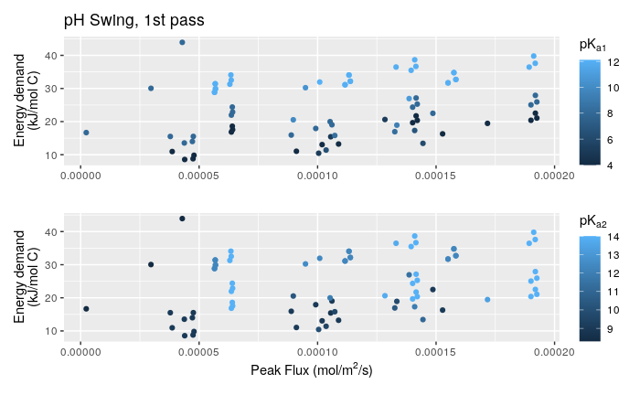

```r
# Kinetics vs energy
# g1 = ggplot(filter(boundary.case, DIC.flux > 0)) +
#   geom_point(mapping = aes(x = DIC.flux, y = Energy.sep, color = -log10(k1))) +
#   labs(x = "", y = "Energy demand\n(kJ/mol C)", color = expression("pK"[a1]), title = "pH Swing, 1st pass")
# g2 = ggplot(filter(boundary.case, DIC.flux > 0)) +
#   geom_point(mapping = aes(x = DIC.flux, y = Energy.sep, color = -log10(k2))) +
#   labs(x = expression("Peak Flux (mol/m"^2*"/s)"), y = "Energy demand\n(kJ/mol C)", color = expression("pK"[a2]))
# g3 = ggplot(filter(boundary.case, DIC.flux > 0)) +
#   geom_point(mapping = aes(x = DIC.flux, y = Energy.sep, color = A)) +
#   labs(x = expression("Peak Flux (mol/m"^2*"/s)"), y = "Energy demand\n(kJ/mol C)", color = expression("[A]"))
# g1 / g2
# g3
#
# g1 = ggplot(filter(boundary.case, DIC.flux > 0)) +
#   geom_point(mapping = aes(x = kin.pk, y = Energy.sep, color = -log10(k1))) +
#   labs(x = "", y = "Energy demand\n(kJ/mol C)", color = expression("pK"[a1]), title = "pH Swing, 1st pass")
# g2 = ggplot(filter(boundary.case, DIC.flux > 0)) +
#   geom_point(mapping = aes(x = kin.pk, y = Energy.sep, color = -log10(k2))) +
#   labs(x = expression("Peak Kinetic Driving Force = k"[H]*" \u0394P"[CO2]*" E"), y = "Energy demand\n(kJ/mol C)", color = expression("pK"[a2]))
# g3 = ggplot(filter(boundary.case, DIC.flux > 0)) +
#   geom_point(mapping = aes(x = kin.pk, y = Energy.sep, color = A)) +
#   labs(x = expression("Peak Kinetic Driving Force = k"[H]*" \u0394P"[CO2]*" E"), y = "Energy demand\n(kJ/mol C)", color = expression("[A]"))
# g1 / g2
# g3
#
# g1 = ggplot(filter(boundary.case, DIC.flux > 0)) +
#   geom_point(mapping = aes(x = E.avg, y = Energy.sep, color = -log10(k1))) +
#   labs(x = "", y = "Energy demand\n(kJ/mol C)", color = expression("pK"[a1]), title = "pH Swing, 1st pass")
# g2 = ggplot(filter(boundary.case, DIC.flux > 0)) +
#   geom_point(mapping = aes(x = E.avg, y = Energy.sep, color = -log10(k2))) +
#   labs(x = "Average enhancement factor", y = "Energy demand\n(kJ/mol C)", color = expression("pK"[a2]))
# g3 = ggplot(filter(boundary.case, DIC.flux > 0)) +
#   geom_point(mapping = aes(x = E.avg, y = Energy.sep, color = A)) +
#   labs(x = "Average enhancement factor", y = "Energy demand\n(kJ/mol C)", color = expression("[A]"))
# g1 / g2
# g3


g1 = ggplot(filter(boundary.case, DIC.flux > 0)) +
  geom_point(mapping = aes(x = DIC.flux, y = Energy.sep, color = -log10(k1))) +
  labs(x = "", y = "Energy demand\n(kJ/mol C)", color = expression("pK"[a1]), title = "pH Swing, 1st pass")
g2 = ggplot(filter(boundary.case, DIC.flux > 0)) +
  geom_point(mapping = aes(x = DIC.flux, y = Energy.sep, color = -log10(k2))) +
  labs(x = expression("Peak Flux (mol/m"^2*"/s)"), y = "Energy demand\n(kJ/mol C)", color = expression("pK"[a2]))
g3 = ggplot(filter(boundary.case, DIC.flux > 0)) +
  geom_point(mapping = aes(x = DIC.flux, y = Energy.sep, color = A)) +
  labs(x = expression("Peak Flux (mol/m"^2*"/s)"), y = "Energy demand\n(kJ/mol C)", color = expression("[A]"))
g1 / g2
```

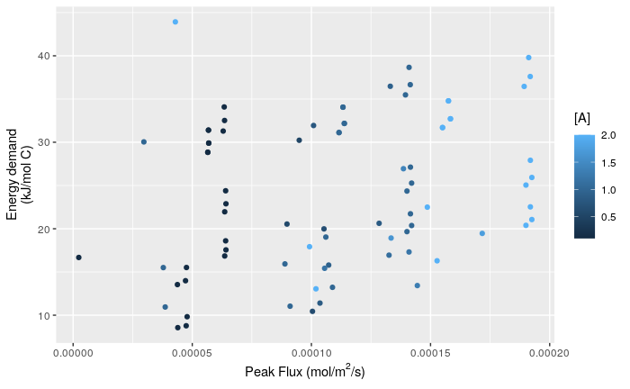

```r
g3
```

```r
rm(g1, g2, g3)
```

```r
# Normalize the x,y by setting the minimum to 0 and the maximum to 1
norm.xy = function(data.xy){
  # Data.xy is a dataframe with columns x and y
  # Set the 0 to the minimum positive point
  data.xy$x = data.xy$x - min(filter(data.xy, x >= 0)$x)
  data.xy$y = data.xy$y - min(filter(data.xy, y >= 0)$y)
  # Normalize to the highest point
  data.xy$x = data.xy$x/max(data.xy$x)
  data.xy$y = data.xy$y/max(data.xy$y)
  return(data.xy)
}
boundary.norm = norm.xy(data.xy = data.frame(x = boundary.case$DIC.flux, y = boundary.case$Energy.sep))

# Obtain the hull space of the first quadrant
hull.full = function(data.xy){
  # Data.xy is a dataframe with columns x and y

  # Hull space describes only the first quadrant
  x.sub = filter(data.xy, x > 0, y >= 0)$x
  y.sub = filter(data.xy, x > 0, y >= 0)$y

  # Hull indices
  hull.indx = chull(x = x.sub, y = y.sub);
  # Hull vertices
  x.boundary = x.sub[hull.indx]; y.boundary = y.sub[hull.indx]
  return(data.frame(x.boundary, y.boundary))
}
hull.boundary = hull.full(data.xy = data.frame(x = boundary.case$DIC.flux, y = boundary.case$Energy.sep))
# Close the hull.boundary for plotting
hull.boundary = rbind(hull.boundary, hull.boundary[1,])
# Obtain the normalized hull for analysis
hull.boundary.norm = hull.full(data.xy = boundary.norm)

hull.segment = function(x.boundary, y.boundary){
  # x.boundary and y.boundary are the vertices of the hull space
  # output is going to give the optimal edge, defined as the path from the minimum y point to the maximum x point (lower right edge)
  # Find the maximum x and minimum y in the hull space
  x.max.pos = which.max(x.boundary); y.min.pos = which.min(y.boundary)
  pos = c(x.max.pos, y.min.pos)
  # Two possible segments
  x.segment1 = x.boundary[seq(from = min(pos), to = max(pos))];   y.segment1 = y.boundary[seq(from = min(pos), to = max(pos))]
  x.segment2 = x.boundary[-seq(from = min(pos)+1, to = max(pos)-1)];  y.segment2 = y.boundary[-seq(from = min(pos)+1, to = max(pos)-1)]
  # The segment to keep is the one with the lowest median y value
  # indx = sort(x.segment1, index.return = TRUE)
  # x.segment1 = x.segment1[indx$ix]; y.segment1 = y.segment1[indx$ix]
  # indx = sort(x.segment2, index.return = TRUE)
  # x.segment2 = x.segment2[indx$ix]; y.segment2 = y.segment2[indx$ix]
  if(median(y.segment1) > median(y.segment2)){
    optim.edge.x = x.segment2
    optim.edge.y = y.segment2
  } else{
    optim.edge.x = x.segment1
    optim.edge.y = y.segment1
  }

  # Accounting for the possibility of the fastest rate having multiple points, only take the lower y value
  pos = which(optim.edge.x == max(optim.edge.x))
  if(length(pos) > 1){
    pos.check = which(optim.edge.y[pos] > min(optim.edge.y[pos]))
    optim.edge.x = optim.edge.x[-pos[pos.check]]
    optim.edge.y = optim.edge.y[-pos[pos.check]]
  }
  # Similarly, if the lowest energy has 2 possible rates, take the faster
  pos = which(optim.edge.y == min(optim.edge.y))
  if(length(pos) > 1){
    pos.check = which(optim.edge.x[pos] < max(optim.edge.x[pos]))
    optim.edge.x = optim.edge.x[-pos[pos.check]]
    optim.edge.y = optim.edge.y[-pos[pos.check]]
  }
  return(data.frame(optim.edge.x, optim.edge.y))
}
# Optimal edge for plotting
optim.edge = hull.segment(x.boundary = hull.boundary$x.boundary, y.boundary = hull.boundary$y.boundary)
# Optimal edge for distance calculation
optim.edge.norm = hull.segment(x.boundary = hull.boundary.norm$x.boundary, y.boundary = hull.boundary.norm$y.boundary)

# Calculate the distance for each point in the data set
min.dist = function(point.x, point.y, edge){
  # point.x and point.y are single values
  # optim.edge is the dataframe output from the hull.segment function
  # If the x point is 0, then omit (distance is NaN)
  # if(point.x <= 0){
  #   return(sqrt(2)) # Maximum distance possible is sqrt(1^2 + 1^2)
  # } else{
    # Simplify to rows, each of a single segment
    edge.semgents = data.frame(point1.x = edge$optim.edge.x[1:(length(edge$optim.edge.x)-1)],
                          point1.y = edge$optim.edge.y[1:(length(edge$optim.edge.y)-1)],
                          point2.x = edge$optim.edge.x[2:(length(edge$optim.edge.x))],
                          point2.y = edge$optim.edge.y[2:(length(edge$optim.edge.y))])
    edge.semgents$seg.len = sqrt((edge.semgents$point1.x - edge.semgents$point2.x)^2 + (edge.semgents$point1.y - edge.semgents$point2.y)^2)
    # Find the area of the triangle for each segment
    dist = c()
    for(pos in 1:length(edge.semgents$point1.x)){
      area = polyarea(x = c(edge.semgents$point1.x[pos], edge.semgents$point2.x[pos], point.x),
                      y = c(edge.semgents$point1.y[pos], edge.semgents$point2.y[pos], point.y))
      dist[pos] = 2*area/edge.semgents$seg.len[pos]
    }
    # Take the minimum distance
    return(min(abs(dist)))
  # }
  # return(edge.semgents)
}

# Run in parallel to speed up calculation. Best way to do this is a foreach loop
dist = foreach(row = 1:length(boundary.norm$x)) %dopar%
  min.dist(point.x = boundary.norm$x[row], point.y = boundary.norm$y[row], edge = optim.edge.norm)
# Store unlisted values in both the normalized and original data
boundary.case$dist = unlist(dist)
boundary.norm$dist = unlist(dist)

# Percentiles
indx = sort(boundary.norm$dist, index.return = TRUE)
boundary.norm = boundary.norm[indx$ix,]
boundary.case = boundary.case[indx$ix,]
boundary.norm$dist.perc = 1:length(boundary.norm$dist)/length(boundary.norm$dist)
boundary.case$dist.perc = 1:length(boundary.case$dist)/length(boundary.case$dist)
boundary.case
```

|  | Na.shift | A | k1 | k2 | beta1 | Na | beta2 | it.num | DIC.diff | pCO2.lean | Energy.sep | DIC.flux | dist | dist.perc |
| --- | --- | --- | --- | --- | --- | --- | --- | --- | --- | --- | --- | --- | --- | --- |
| 30 | 0.100000000 | 0.1000000 | 1.000000e-04 | 1.000000e-09 | 0 | 0.008750000 | 0 | 0 | 0.13520409 | 4.116907e-03 | 8.558380 | 4.3924e-05 | 0.00000000 | 0.01 |
| 62 | 0.000000000 | 2.0000000 | 1.000000e-04 | 1.000000e-14 | 0 | -0.025000000 | 0 | 0 | 3.54205926 | 3.182330e-11 | 21.061429 | 1.9252e-04 | 0.00000000 | 0.02 |
| 63 | 0.100000000 | 2.0000000 | 1.000000e-04 | 1.000000e-14 | 0 | 0.175000000 | 0 | 0 | 3.52074327 | 1.061679e-10 | 20.391100 | 1.9004e-04 | 0.00000000 | 0.03 |
| 85 | 0.032024465 | 0.6196317 | 7.186880e-06 | 1.122686e-10 | 0 | 0.012097977 | 0 | 0 | 1.01786203 | 4.224778e-04 | 10.446274 | 1.0045e-04 | 0.00000000 | 0.04 |
| 99 | 0.070012035 | 1.3082464 | 8.872004e-07 | 9.000136e-12 | 0 | 0.075239912 | 0 | 0 | 2.30505639 | 1.995179e-05 | 13.427279 | 1.4446e-04 | 0.00000000 | 0.05 |
| 29 | 0.000000000 | 0.1000000 | 1.000000e-04 | 1.000000e-09 | 0 | -0.001250000 | 0 | 0 | 0.13642016 | 3.245586e-03 | 8.777584 | 4.7444e-05 | 0.00245539 | 0.06 |
| 3 | 0.100000000 | 0.1000000 | 1.000000e-04 | 5.000000e-05 | 0 | 0.008750000 | 0 | 0 | -0.03317330 | 1.115293e+00 | -7.854692 | 0.0000e+00 | 0.01566285 | 0.07 |
| 89 | 0.032719801 | 0.8272551 | 3.388138e-07 | 3.359434e-10 | 0 | 0.016726933 | 0 | 0 | 1.09303563 | 1.778576e-03 | 11.401137 | 1.0359e-04 | 0.01729161 | 0.08 |
| 32 | 0.000000000 | 1.0000000 | 1.000000e-04 | 1.000000e-09 | 0 | -0.012500000 | 0 | 0 | 0.84434373 | 4.362909e-03 | 11.040302 | 9.1059e-05 | 0.02192734 | 0.09 |
| 61 | -0.100000000 | 2.0000000 | 1.000000e-04 | 1.000000e-14 | 0 | -0.225000000 | 0 | 0 | 3.43779482 | 1.033796e-11 | 22.528102 | 1.9190e-04 | 0.02469343 | 0.10 |

[output cut: 90 more lines]

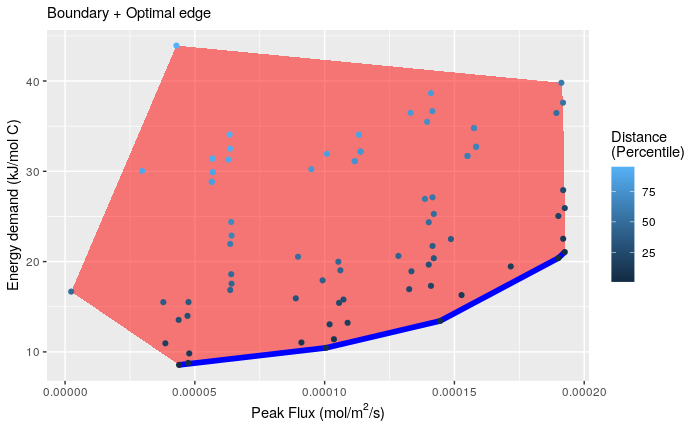

```r
ggplot() +
  geom_polygon(data = hull.boundary, mapping = aes(x = x.boundary, y = y.boundary), fill = alpha("red", 0.5)) +
  geom_path(data = optim.edge, mapping = aes(x = optim.edge.x, y = optim.edge.y), color = "blue", size = 2) +
  geom_point(data = filter(boundary.case, DIC.flux > 0), mapping = aes(x = DIC.flux, y = Energy.sep, color = dist.perc*100)) + # Color as the percentiles
  labs(x = expression("Peak Flux (mol/m"^2*"/s)"),
       y = "Energy demand (kJ/mol C)", subtitle = "Boundary + Optimal edge", color = "Distance\n(Percentile)")
```

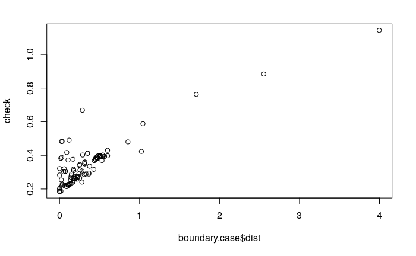

```r
filt1 = randomForest(dist ~ A * k1 * k2 * Na * beta1, data = boundary.case)

# Check the random forrest accuracy
check = predict(filt1, boundary.case)
plot(boundary.case$dist, check)
```

```r
# optim.edge
# Remove variables
rm(boundary.norm, dist, hull.boundary, hull.boundary.norm, indx, optim.edge, optim.edge.norm)
```

```r
# Sampling function
data.iterate.beta = function(forest.object, prev.data, beta2, pCO2.in){ # Creates the next iterations for dataset
  # Set bounds based on bounds of the previous data. The bounds are the weighted average of the total set and the most recent set, weighted by the iteration number. This constrains the points further the more iterations that have been done
  # Total range
  A.range.tot = range(prev.data$A); Na.shift.range.tot = range(prev.data$Na.shift)
  pka1.bound.tot = range(-log10(prev.data$k1)); pka2.bound.tot = range(-log10(prev.data$k2))
  beta1.bound.tot = range(prev.data$beta1)
  # Most recent dataset
  A.range = range(prev.data$A[prev.data$it.num == max(prev.data$it.num)]);
  Na.shift.range = range(prev.data$Na.shift[prev.data$it.num == max(prev.data$it.num)])
  pka1.bound = range(-log10(prev.data$k1[prev.data$it.num == max(prev.data$it.num)]));
  pka2.bound = range(-log10(prev.data$k2[prev.data$it.num == max(prev.data$it.num)]))
  beta1.bound = range(prev.data$beta1[prev.data$it.num == max(prev.data$it.num)])
  # Weighted average
  A.range = (A.range*max(prev.data$it.num) + A.range.tot)/(max(prev.data$it.num) + 1)
  Na.shift.range = (Na.shift.range*max(prev.data$it.num) + Na.shift.range.tot)/(max(prev.data$it.num) + 1)
  pka1.bound = (pka1.bound*max(prev.data$it.num) + pka1.bound.tot)/(max(prev.data$it.num) + 1)
  pka2.bound = (pka2.bound*max(prev.data$it.num) + pka2.bound.tot)/(max(prev.data$it.num) + 1)
  beta1.bound = (beta1.bound*max(prev.data$it.num) + beta1.bound.tot)/(max(prev.data$it.num) + 1)

  # Set length is based on the number of variables included; it is the same each iteration for simplicty
  len = length(prev.data$A[prev.data$it.num == 0])

  # Determine the cutoff value for the distance
  perc.cutoff = 0.8*0.5^max(prev.data$it.num)
  dist = sort(prev.data$dist)
  cutoff.pos = floor(perc.cutoff*length(dist))
  dist.cutoff = dist[cutoff.pos]

  # Randomly sample at least 100 points that, according to the random forest, would meet the criteria
  test.set = data.frame(A = runif(n = len*2, min = min(A.range), max = max(A.range)), # Use double the target because so many will be removed
                        Na.shift = runif(n = len*2, min = min(Na.shift.range), max = max(Na.shift.range)),
                        k1 = 10^-runif(n = len*2, min = min(pka1.bound)-0.1, max = max(pka1.bound)+0.1),
                        k2 = 10^-runif(n = len*2, min = min(pka2.bound)-0.1, max = max(pka2.bound)+0.1),
                        beta1 = runif(n = len*2, min = min(beta1.bound), max = max(beta1.bound))) # Expand the pka range out slightly
                                                                                                  # for better histograms later
  test.set$Na = (test.set$Na.shift-0.025*0.5)*test.set$A
  test.set$beta2 = beta2
  # Determine reject if pka1 > pka2
  test.set = filter(test.set, k2 < k1)
  # Calculate the predicted distance from the line, apply the cutoff value
  test.set$dist = predict(forest.object, test.set)
  test.set = filter(test.set, dist < dist.cutoff)
  # Remove points with insufficient capture
  if(length(test.set$A) > 0){
    test.set$pCO2.lean = mcmapply(pCO2.lean, Na = test.set$Na, A =  test.set$A, beta1 = test.set$beta1, beta2 = test.set$beta2,
                                k1 = test.set$k1, k2 = test.set$k2, pCO2.out = 1)
    test.set = filter(test.set, pCO2.lean < 0.1*pCO2.in)
  }

  while(length(test.set$A) < len){
    add = (len - length(test.set$A))*2 # Get double the points as the cutoff; more is better
    # New option
    new.point = data.frame(A = runif(n = add, min = min(A.range), max = max(A.range)),
                           Na.shift = runif(n = add, min = min(Na.shift.range), max = max(Na.shift.range)),
                           k1 = 10^-runif(n = add, min = min(pka1.bound)-0.1, max = max(pka1.bound)+0.1),
                           k2 = 10^-runif(n = add, min = min(pka2.bound)-0.1, max = max(pka2.bound)+0.1),
                           beta1 = runif(n = add, min = min(beta1.bound), max = max(beta1.bound)))
    new.point$Na = (new.point$Na.shift-0.025*0.5)*new.point$A
    new.point$beta2 = beta2
    # Apply constraints: as before, in order to minimize number of time-consuming calculations
    new.point = filter(new.point, k2 < k1)
    new.point$dist = predict(forest.object, new.point)
    new.point = filter(new.point, dist < dist.cutoff)
    if(length(new.point$A) > 0){ # Errors in calculation if the new points don't meet the criteria to begin with
      new.point$pCO2.lean = mcmapply(pCO2.lean, Na = new.point$Na, A =  new.point$A, beta1 = new.point$beta1, beta2 = new.point$beta2,
                                k1 = new.point$k1, k2 = new.point$k2, pCO2.out = 1)
      new.point = filter(new.point, pCO2.lean < 0.1*pCO2.in)
    }
    # Accept the new point if the new probability (unweighted) is greater than the adjusted probability of the previous point
    test.set = rbind(test.set, new.point)
  }
  test.set$it.num = max(prev.data$it.num) + 1
  return(test.set[1:len, ]) # Only the first X points, where x is the target length. Cut off extra points for analysis purposes
}
```

```r
# Create a loop to iterate
sys.iterate = function(data.start, filt.start, n){
  data = data.start; filt = filt.start
  for(i in 1:n){
    ## New points for next iteration
    dat = data.iterate.beta(forest.object = filt, prev.data = data, beta2 = data$beta2[1], pCO2.in = 0.15)
    # return(dat)
    # Calculate DIC difference and total energy deman
    dat$DIC.diff = mcmapply(DIC.diff, Na = dat$Na, A =  dat$A, beta1 = dat$beta1, beta2 = dat$beta2,
                                      k1 = dat$k1, k2 = dat$k2, pCO2.in = 0.15, pCO2.out = 1)
    Energy.J.L = mcmapply(Energy.tot, k1 = dat$k1, k2 = dat$k2,
               beta1 = dat$beta1, beta2 = dat$beta2,
               A.tot = dat$A,     Na = dat$Na,
               pCO2.in = 0.15, pCO2.out = 1, mc.cores = 2)
    dat$Energy.sep = Energy.J.L/dat$DIC.diff*1e-3
    # Calculate kinetic factors
    kinetic = mcmapply(kinetic.force, k1 = dat$k1, k2 = dat$k2, beta1 = dat$beta1, beta2 = dat$beta2,
                  A.tot = dat$A, Na = dat$Na, pCO2.in = 0.15, pCO2.out = 1)
    dat$DIC.flux = kinetic
    # dat

    ## Re-calculate the hull space and distance
    # Normalize
    dat.all = filter(rbind(dat, data[names(data) != "dist.perc"]), Energy.sep < 100)
    dat.norm = norm.xy(data.xy = data.frame(x = dat.all$DIC.flux, y = dat.all$Energy.sep))

    # Obtain the hull space of the first quadrant
    hull.dat = hull.full(data.xy = data.frame(x = dat.all$DIC.flux, y = dat.all$Energy.sep))
    # Close the hull.boundary for plotting
    hull.dat = rbind(hull.dat, hull.dat[1,])
    # Obtain the normalized hull for analysis
    hull.dat.norm = hull.full(data.xy = dat.norm)

    # Optimal edge for plotting
    optim.edge1 = hull.segment(x.boundary = hull.dat$x.boundary, y.boundary = hull.dat$y.boundary)
    # Optimal edge for distance calculation
    optim.edge1.norm = hull.segment(x.boundary = hull.dat.norm$x.boundary, y.boundary = hull.dat.norm$y.boundary)

    # Calculate distance in parallel to speed up calculation. Best way to do this is a foreach loop
    dist = foreach(row = 1:length(dat.norm$x)) %dopar%
      min.dist(point.x = dat.norm$x[row], point.y = dat.norm$y[row], edge = optim.edge1.norm)
    # Store unlisted values in both the normalized and original data
    dat.all$dist = unlist(dist)
    dat.norm$dist = unlist(dist)

    # Percentiles
    indx = sort(dat.norm$dist, index.return = TRUE)
    dat.all = dat.all[indx$ix,]
    dat.all$dist.perc = 1:length(dat.all$dist)/length(dat.all$dist)

    # Save for next loop
    data = dat.all
    filt = randomForest(dist ~ A * k1 * k2 * Na * beta1, data = data, mtry = 10)
  }
  return(dat.all)
}

iterate.beta0 = sys.iterate(data = boundary.case, filt = filt1, n = 2)
```

```
invalid mtry: reset to within valid rangeinvalid mtry: reset to within valid range
```

```r
# To save time, if already run, load the file instead
# iterate.beta0 = read.csv("SorbentActivation-2e-MonteCarlo-HullPerimeterDistance-v3-beta2-0e0.csv")

# Run another iteration. Separate this to account for possible interruptions partway.
filt1 = randomForest(dist ~ A * k1 * k2 * Na.shift * beta1, data = iterate.beta0, mtry = 10)
```

```
invalid mtry: reset to within valid range
```

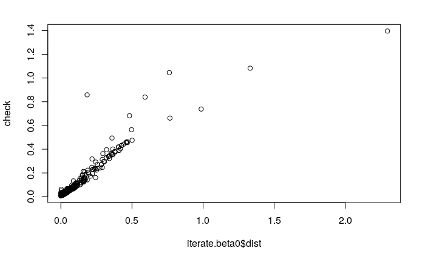

```r
check = predict(filt1, iterate.beta0)
plot(iterate.beta0$dist, check)
```

```r
iterate.beta0 = sys.iterate(data = iterate.beta0, filt = filt1, n = 1)
```

```
invalid mtry: reset to within valid range
```

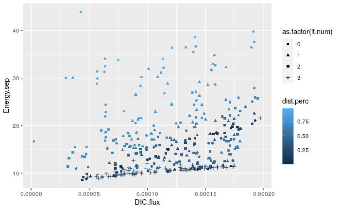

```r
ggplot() +
  geom_point(data = filter(iterate.beta0, DIC.flux > 0), mapping = aes(x = DIC.flux, y = Energy.sep, color = dist.perc, shape = as.factor(it.num)))
```

```r
write.csv(iterate.beta0, "SorbentActivation-2e-MonteCarlo-HullPerimeterDistance-v3-beta2-0e0.csv", row.names = FALSE)
```

```r
filter.create = function(dat){ # Create the dataframe for the filter, not the filter itself
  ## Calculate the hull space and distance to get the first filter function
  # Normalize
  dat.all = filter(dat, Energy.sep < 100)
  dat.norm = norm.xy(data.xy = data.frame(x = dat.all$DIC.flux, y = dat.all$Energy.sep))

  # Obtain the hull space of the first quadrant
  hull.dat = hull.full(data.xy = data.frame(x = dat.all$DIC.flux, y = dat.all$Energy.sep))
  # Close the hull.boundary for plotting
  hull.dat = rbind(hull.dat, hull.dat[1,])
  # Obtain the normalized hull for analysis
  hull.dat.norm = hull.full(data.xy = dat.norm)

  # Optimal edge for plotting
  optim.edge1 = hull.segment(x.boundary = hull.dat$x.boundary, y.boundary = hull.dat$y.boundary)
  # Optimal edge for distance calculation
  optim.edge1.norm = hull.segment(x.boundary = hull.dat.norm$x.boundary, y.boundary = hull.dat.norm$y.boundary)

  # Calculate distance in parallel to speed up calculation. Best way to do this is a foreach loop
  dist = foreach(row = 1:length(dat.norm$x)) %dopar%
    min.dist(point.x = dat.norm$x[row], point.y = dat.norm$y[row], edge = optim.edge1.norm)
  # Store unlisted values in both the normalized and original data
  dat.all$dist = unlist(dist)
  dat.norm$dist = unlist(dist)

  # Percentiles
  indx = sort(dat.norm$dist, index.return = TRUE)
  dat.all = dat.all[indx$ix,]
  dat.all$dist.perc = 1:length(dat.all$dist)/length(dat.all$dist)
  return(dat.all)
}

randomForest(dist ~ A * k1 * k2 * Na * beta1, data = filter.create(dat = iterate.beta0))
```

```
Call:
 randomForest(formula = dist ~ A * k1 * k2 * Na * beta1, data = filter.create(dat = iterate.beta0))
               Type of random forest: regression
                     Number of trees: 500
No. of variables tried at each split: 1

          Mean of squared residuals: 0.1457413
                    % Var explained: 34.46
```

```r
# Run process with other beta - target values: 0, 1, 10, 100, 1e4, 1e6
boundary.case = boundary.setup(beta2 = 1e1)

# Run the DIC and energy demand on this set of inputs. Use best case flue gas conditions. Only interested in the separate case, for the simplicity of testing the method
boundary.case$DIC.diff = mcmapply(DIC.diff, Na = boundary.case$Na, A =  boundary.case$A, beta1 = boundary.case$beta1, beta2 = boundary.case$beta2,
                                  k1 = boundary.case$k1, k2 = boundary.case$k2, pCO2.in = 0.15, pCO2.out = 1)
boundary.case$pCO2.lean = mcmapply(pCO2.lean, Na = boundary.case$Na, A =  boundary.case$A, beta1 = boundary.case$beta1, beta2 = boundary.case$beta2,
                                  k1 = boundary.case$k1, k2 = boundary.case$k2, pCO2.out = 1)
Energy.J.L = mcmapply(Energy.tot, k1 = boundary.case$k1, k2 = boundary.case$k2,
           beta1 = boundary.case$beta1, beta2 = boundary.case$beta2,
           A.tot = boundary.case$A, Na = boundary.case$Na,
           pCO2.in = 0.15, pCO2.out = 1, mc.cores = 3)
boundary.case$Energy.sep = Energy.J.L/boundary.case$DIC.diff*1e-3
# Energy.J.L
# Remove temp variables that sometimes appear
var = c("Na.shift", "A", "k1", "k2", "beta1", "Na", "beta2", "it.num", "DIC.diff", "pCO2.lean", "Energy.sep")
boundary.case = boundary.case[var] # Eliminate metadata from the function calls

# Kinetics
kinetic = mcmapply(kinetic.force, k1 = boundary.case$k1, k2 = boundary.case$k2,
                   beta1 = boundary.case$beta1, beta2 = boundary.case$beta2,
                   A.tot = boundary.case$A, Na = boundary.case$Na, pCO2.in = 0.15, pCO2.out = 1)
# kinetic
boundary.case$DIC.flux = kinetic
# boundary.case

# Create filter for next iteration
boundary.case = filter.create(dat = boundary.case)
filt1 = randomForest(dist ~ A * k1 * k2 * Na * beta1, data = boundary.case)

# Iterate
iterate.beta1 = sys.iterate(data = boundary.case, filt = filt1, n = 2)
```

```
invalid mtry: reset to within valid rangeinvalid mtry: reset to within valid range
```

```r
# To save time, if already run, load the file instead
# iterate.beta1 = read.csv("SorbentActivation-2e-MonteCarlo-HullPerimeterDistance-v3-beta2-1e1.csv")
# Run another iteration, separated in case of errors (happens frequently enough)
filt1 = randomForest(dist ~ A * k1 * k2 * Na.shift * beta1, data = iterate.beta1, mtry = 10)
```

```
invalid mtry: reset to within valid range
```

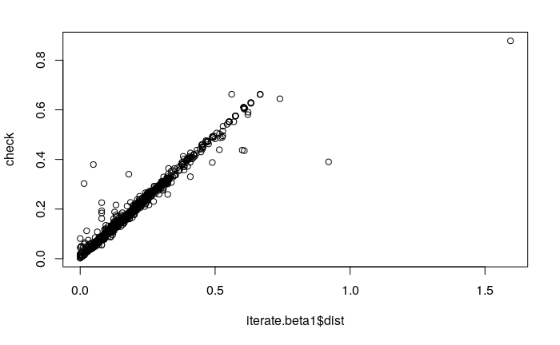

```r
check = predict(filt1, iterate.beta1)
plot(iterate.beta1$dist, check)
```

```r
iterate.beta1 = sys.iterate(data = iterate.beta1, filt = filt1, n = 1)
```

```
invalid mtry: reset to within valid range
```

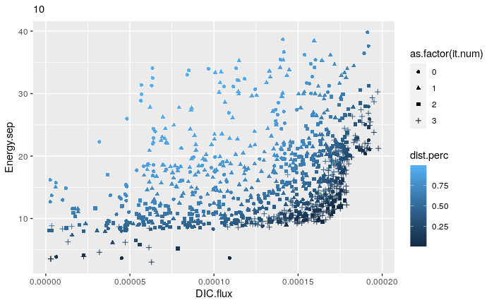

```r
# iterate.beta1
ggplot() +
  geom_point(data = filter(iterate.beta1, DIC.flux > 0), mapping = aes(x = DIC.flux, y = Energy.sep, color = dist.perc, shape = as.factor(it.num))) +
  labs(subtitle = iterate.beta1$beta2[1])
```

```r
write.csv(iterate.beta1, "SorbentActivation-2e-MonteCarlo-HullPerimeterDistance-v3-beta2-1e1.csv", row.names = FALSE)
```

```r
# Run process with other beta - target values: 0, 1, 10, 100, 1e4, 1e6
boundary.case = boundary.setup(beta2 = 1e2)

# Run the DIC and energy demand on this set of inputs. Use best case flue gas conditions. Only interested in the separate case, for the simplicity of testing the method
boundary.case$DIC.diff = mcmapply(DIC.diff, Na = boundary.case$Na, A =  boundary.case$A, beta1 = boundary.case$beta1, beta2 = boundary.case$beta2,
                                  k1 = boundary.case$k1, k2 = boundary.case$k2, pCO2.in = 0.15, pCO2.out = 1)
boundary.case$pCO2.lean = mcmapply(pCO2.lean, Na = boundary.case$Na, A =  boundary.case$A, beta1 = boundary.case$beta1, beta2 = boundary.case$beta2,
                                  k1 = boundary.case$k1, k2 = boundary.case$k2, pCO2.out = 1)
Energy.J.L = mcmapply(Energy.tot, k1 = boundary.case$k1, k2 = boundary.case$k2,
           beta1 = boundary.case$beta1, beta2 = boundary.case$beta2,
           A.tot = boundary.case$A, Na = boundary.case$Na,
           pCO2.in = 0.15, pCO2.out = 1, mc.cores = 3)
boundary.case$Energy.sep = Energy.J.L/boundary.case$DIC.diff*1e-3
# Energy.J.L
# Remove temp variables that sometimes appear
var = c("Na.shift", "A", "k1", "k2", "beta1", "Na", "beta2", "it.num", "DIC.diff", "pCO2.lean", "Energy.sep")
boundary.case = boundary.case[var] # Eliminate metadata from the function calls

# Kinetics
kinetic = mcmapply(kinetic.force, k1 = boundary.case$k1, k2 = boundary.case$k2,
                   beta1 = boundary.case$beta1, beta2 = boundary.case$beta2,
                   A.tot = boundary.case$A, Na = boundary.case$Na, pCO2.in = 0.15, pCO2.out = 1)
# kinetic
boundary.case$DIC.flux = kinetic
# boundary.case

# Create filter for next iteration
boundary.case = filter.create(dat = boundary.case)
filt1 = randomForest(dist ~ A * k1 * k2 * Na * beta1, data = boundary.case)

# Iterate
iterate.beta1 = sys.iterate(data = boundary.case, filt = filt1, n = 2)
```

```
invalid mtry: reset to within valid rangeinvalid mtry: reset to within valid range
```

```r
# iterate.beta1
# To save time, if already run, load the file instead
# iterate.beta1 = read.csv("SorbentActivation-2e-MonteCarlo-HullPerimeterDistance-v3-beta2-1e2.csv")
# Run another iteration, separated for possible errors
filt1 = randomForest(dist ~ A * k1 * k2 * Na.shift * beta1, data = iterate.beta1, mtry = 10)
```

```
invalid mtry: reset to within valid range
```

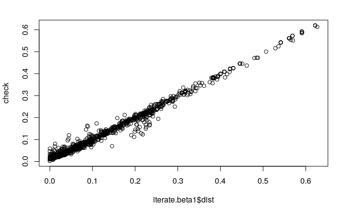

```r
check = predict(filt1, iterate.beta1)
plot(iterate.beta1$dist, check)
```

```r
iterate.beta1 = sys.iterate(data = iterate.beta1, filt = filt1, n = 1)
```

```
invalid mtry: reset to within valid range
```

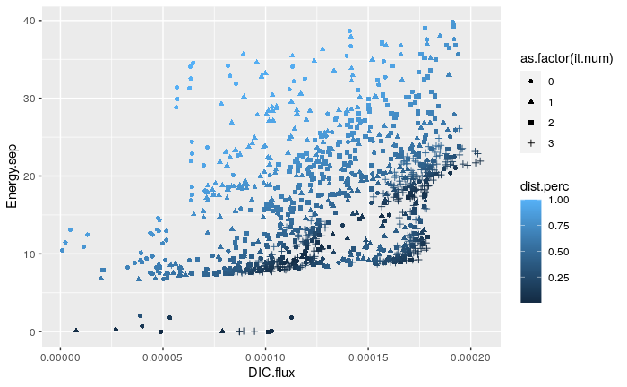

```r
ggplot() +
  geom_point(data = filter(iterate.beta1, DIC.flux > 0), mapping = aes(x = DIC.flux, y = Energy.sep, color = dist.perc, shape = as.factor(it.num)))
```

```r
write.csv(iterate.beta1, "SorbentActivation-2e-MonteCarlo-HullPerimeterDistance-v3-beta2-1e2.csv", row.names = FALSE)
```

```r
boundary.case = boundary.setup(beta2 = 1e0)

# Run the DIC and energy demand on this set of inputs. Use best case flue gas conditions. Only interested in the separate case, for the simplicity of testing the method
boundary.case$DIC.diff = mcmapply(DIC.diff, Na = boundary.case$Na, A =  boundary.case$A, beta1 = boundary.case$beta1, beta2 = boundary.case$beta2,
                                  k1 = boundary.case$k1, k2 = boundary.case$k2, pCO2.in = 0.15, pCO2.out = 1)
boundary.case$pCO2.lean = mcmapply(pCO2.lean, Na = boundary.case$Na, A =  boundary.case$A, beta1 = boundary.case$beta1, beta2 = boundary.case$beta2,
                                  k1 = boundary.case$k1, k2 = boundary.case$k2, pCO2.out = 1)
Energy.J.L = mcmapply(Energy.tot, k1 = boundary.case$k1, k2 = boundary.case$k2,
           beta1 = boundary.case$beta1, beta2 = boundary.case$beta2,
           A.tot = boundary.case$A, Na = boundary.case$Na,
           pCO2.in = 0.15, pCO2.out = 1, mc.cores = 3)
boundary.case$Energy.sep = Energy.J.L/boundary.case$DIC.diff*1e-3
# Energy.J.L
# Remove temp variables that sometimes appear
var = c("Na.shift", "A", "k1", "k2", "beta1", "Na", "beta2", "it.num", "DIC.diff", "pCO2.lean", "Energy.sep")
boundary.case = boundary.case[var] # Eliminate metadata from the function calls

# Kinetics
kinetic = mcmapply(kinetic.force, k1 = boundary.case$k1, k2 = boundary.case$k2,
                   beta1 = boundary.case$beta1, beta2 = boundary.case$beta2,
                   A.tot = boundary.case$A, Na = boundary.case$Na, pCO2.in = 0.15, pCO2.out = 1)
# kinetic
boundary.case$DIC.flux = kinetic
# boundary.case

# Create filter for next iteration
boundary.case = filter.create(dat = boundary.case)
filt1 = randomForest(dist ~ A * k1 * k2 * Na * beta1, data = boundary.case)
# Iterate
iterate.beta1 = sys.iterate(data = boundary.case, filt = filt1, n = 1)
```

```
invalid mtry: reset to within valid range
```

```r
# iterate.beta1
# To save time, if already run, load the file instead
# iterate.beta1 = read.csv("SorbentActivation-2e-MonteCarlo-HullPerimeterDistance-v3-beta2-1e0.csv")
# Run another iteration, separated for possible errors

filt1 = randomForest(dist ~ A * k1 * k2 * Na.shift * beta1, data = iterate.beta1, mtry = 10)
```

```
invalid mtry: reset to within valid range
```

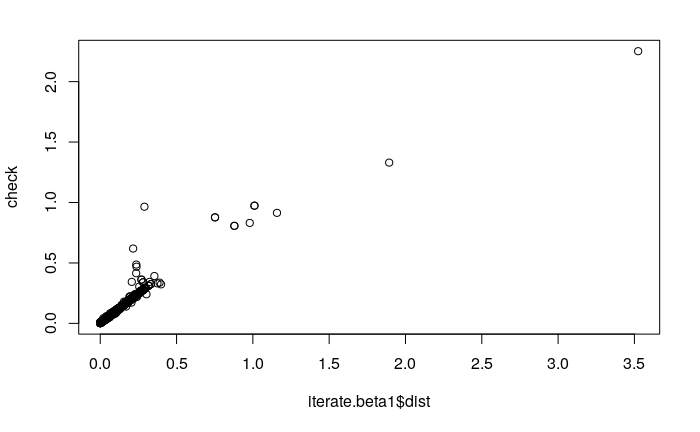

```r
check = predict(filt1, iterate.beta1)
plot(iterate.beta1$dist, check)
```

```r
iterate.beta1 = sys.iterate(data = iterate.beta1, filt = filt1, n = 1)
```

```
invalid mtry: reset to within valid range
```

```r
filt1 = randomForest(dist ~ A * k1 * k2 * Na.shift * beta1, data = iterate.beta1, mtry = 10)
```

```
invalid mtry: reset to within valid range
```

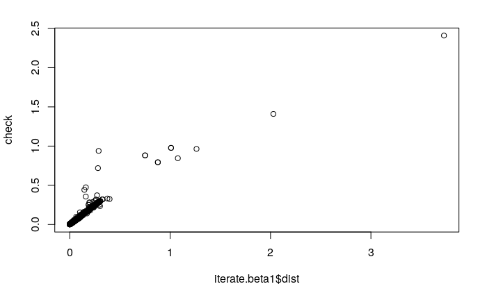

```r
check = predict(filt1, iterate.beta1)
plot(iterate.beta1$dist, check)
```

```r
iterate.beta1 = sys.iterate(data = iterate.beta1, filt = filt1, n = 1)
```

```
invalid mtry: reset to within valid range
```

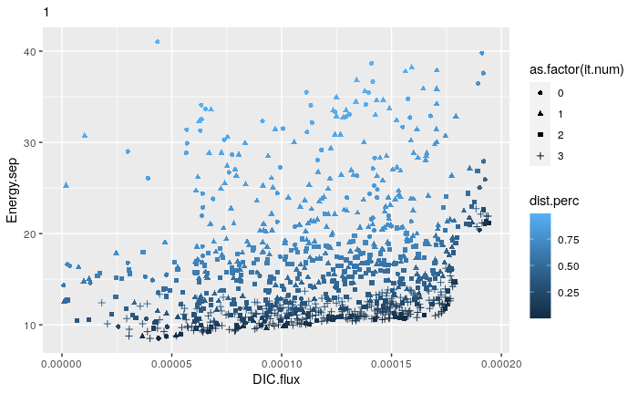

```r
ggplot() +
  geom_point(data = filter(iterate.beta1, DIC.flux > 0), mapping = aes(x = DIC.flux, y = Energy.sep, color = dist.perc, shape = as.factor(it.num))) +
  labs(subtitle = iterate.beta1$beta2[1])
```

```r
write.csv(iterate.beta1, "SorbentActivation-2e-MonteCarlo-HullPerimeterDistance-v3-beta2-1e0.csv", row.names = FALSE)
```

```r
boundary.case = boundary.setup(beta2 = 1e4)

# Run the DIC and energy demand on this set of inputs. Use best case flue gas conditions. Only interested in the separate case, for the simplicity of testing the method
boundary.case$DIC.diff = mcmapply(DIC.diff, Na = boundary.case$Na, A =  boundary.case$A, beta1 = boundary.case$beta1, beta2 = boundary.case$beta2,
                                  k1 = boundary.case$k1, k2 = boundary.case$k2, pCO2.in = 0.15, pCO2.out = 1)
boundary.case$pCO2.lean = mcmapply(pCO2.lean, Na = boundary.case$Na, A =  boundary.case$A, beta1 = boundary.case$beta1, beta2 = boundary.case$beta2,
                                  k1 = boundary.case$k1, k2 = boundary.case$k2, pCO2.out = 1)
Energy.J.L = mcmapply(Energy.tot, k1 = boundary.case$k1, k2 = boundary.case$k2,
           beta1 = boundary.case$beta1, beta2 = boundary.case$beta2,
           A.tot = boundary.case$A, Na = boundary.case$Na,
           pCO2.in = 0.15, pCO2.out = 1, mc.cores = 3)
boundary.case$Energy.sep = Energy.J.L/boundary.case$DIC.diff*1e-3
# Energy.J.L
# Remove temp variables that sometimes appear
var = c("Na.shift", "A", "k1", "k2", "beta1", "Na", "beta2", "it.num", "DIC.diff", "pCO2.lean", "Energy.sep")
boundary.case = boundary.case[var] # Eliminate metadata from the function calls

# Kinetics
kinetic = mcmapply(kinetic.force, k1 = boundary.case$k1, k2 = boundary.case$k2,
                   beta1 = boundary.case$beta1, beta2 = boundary.case$beta2,
                   A.tot = boundary.case$A, Na = boundary.case$Na, pCO2.in = 0.15, pCO2.out = 1)
# kinetic
boundary.case$DIC.flux = kinetic
# boundary.case

# Create filter for next iteration
boundary.case = filter.create(dat = boundary.case)
filt1 = randomForest(dist ~ A * k1 * k2 * Na * beta1, data = boundary.case)

# Iterate
iterate.beta1 = sys.iterate(data = boundary.case, filt = filt1, n = 2)
```

```
invalid mtry: reset to within valid rangeinvalid mtry: reset to within valid range
```

```r
# To save time, if already run, load the file instead
# iterate.beta1 = read.csv("SorbentActivation-2e-MonteCarlo-HullPerimeterDistance-v3-beta2-1e4.csv")
# Run another iteration, separated for possible errors
filt1 = randomForest(dist ~ A * k1 * k2 * Na.shift * beta1, data = iterate.beta1, mtry = 10)
```

```
invalid mtry: reset to within valid range
```

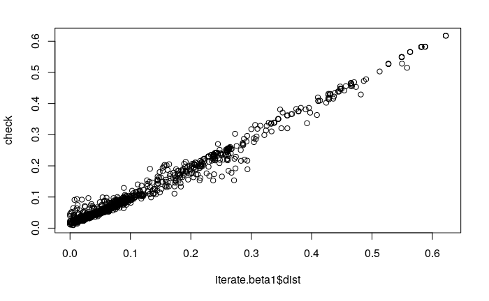

```r
check = predict(filt1, iterate.beta1)
plot(iterate.beta1$dist, check)
```

```r
iterate.beta1 = sys.iterate(data = iterate.beta1, filt = filt1, n = 1)
```

```
invalid mtry: reset to within valid range
```

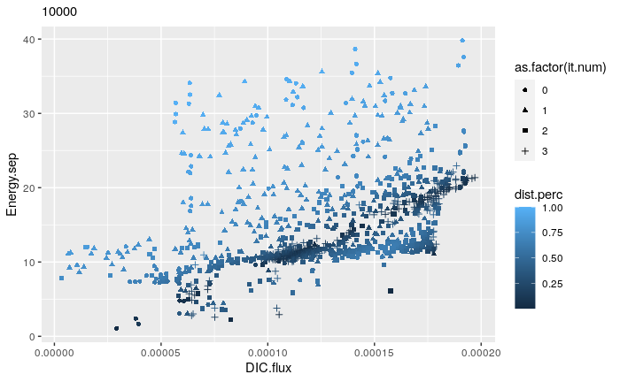

```r
# iterate.beta1
ggplot() +
  geom_point(data = filter(iterate.beta1, DIC.flux > 0), mapping = aes(x = DIC.flux, y = Energy.sep, color = dist.perc, shape = as.factor(it.num))) +
  labs(subtitle = iterate.beta1$beta2[1])
```

```r
write.csv(iterate.beta1, "SorbentActivation-2e-MonteCarlo-HullPerimeterDistance-v3-beta2-1e4.csv", row.names = FALSE)
```

```r
boundary.case = boundary.setup(beta2 = 1e6)

# Run the DIC and energy demand on this set of inputs. Use best case flue gas conditions. Only interested in the separate case, for the simplicity of testing the method
boundary.case$DIC.diff = mcmapply(DIC.diff, Na = boundary.case$Na, A =  boundary.case$A, beta1 = boundary.case$beta1, beta2 = boundary.case$beta2,
                                  k1 = boundary.case$k1, k2 = boundary.case$k2, pCO2.in = 0.15, pCO2.out = 1)
boundary.case$pCO2.lean = mcmapply(pCO2.lean, Na = boundary.case$Na, A =  boundary.case$A, beta1 = boundary.case$beta1, beta2 = boundary.case$beta2,
                                  k1 = boundary.case$k1, k2 = boundary.case$k2, pCO2.out = 1)
Energy.J.L = mcmapply(Energy.tot, k1 = boundary.case$k1, k2 = boundary.case$k2,
           beta1 = boundary.case$beta1, beta2 = boundary.case$beta2,
           A.tot = boundary.case$A, Na = boundary.case$Na,
           pCO2.in = 0.15, pCO2.out = 1, mc.cores = 3)
boundary.case$Energy.sep = Energy.J.L/boundary.case$DIC.diff*1e-3
# Energy.J.L
# Remove temp variables that sometimes appear
var = c("Na.shift", "A", "k1", "k2", "beta1", "Na", "beta2", "it.num", "DIC.diff", "pCO2.lean", "Energy.sep")
boundary.case = boundary.case[var] # Eliminate metadata from the function calls

# Kinetics
kinetic = mcmapply(kinetic.force, k1 = boundary.case$k1, k2 = boundary.case$k2,
                   beta1 = boundary.case$beta1, beta2 = boundary.case$beta2,
                   A.tot = boundary.case$A, Na = boundary.case$Na, pCO2.in = 0.15, pCO2.out = 1)
# kinetic
boundary.case$DIC.flux = kinetic
# boundary.case

# Create filter for next iteration
boundary.case = filter.create(dat = boundary.case)
filt1 = randomForest(dist ~ A * k1 * k2 * Na * beta1, data = boundary.case)

# Iterate
iterate.beta1 = sys.iterate(data = boundary.case, filt = filt1, n = 2)
```

```
invalid mtry: reset to within valid rangeinvalid mtry: reset to within valid range
```

```r
# iterate.beta1
# To save time, if already run, load the file instead
# iterate.beta1 = read.csv("SorbentActivation-2e-MonteCarlo-HullPerimeterDistance-v3-beta2-1e6.csv")
# Run another iteration, separated for possible errors
filt1 = randomForest(dist ~ A * k1 * k2 * Na.shift * beta1, data = iterate.beta1, mtry = 10)
```

```
invalid mtry: reset to within valid range
```

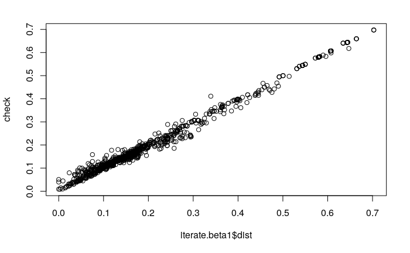

```r
check = predict(filt1, iterate.beta1)
plot(iterate.beta1$dist, check)
```

```r
iterate.beta1 = sys.iterate(data = iterate.beta1, filt = filt1, n = 1)
```

```
invalid mtry: reset to within valid range
```

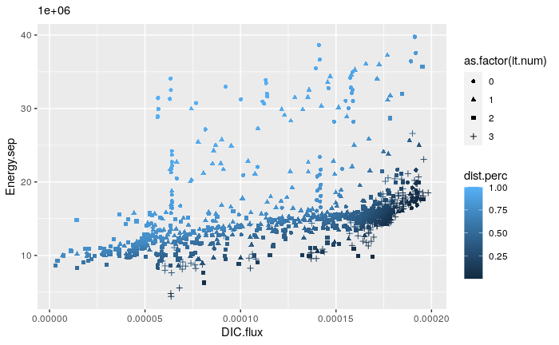

```r
ggplot() +
  geom_point(data = filter(iterate.beta1, DIC.flux > 0), mapping = aes(x = DIC.flux, y = Energy.sep, color = dist.perc, shape = as.factor(it.num))) +
  labs(subtitle = iterate.beta1$beta2[1])
```

```r
write.csv(iterate.beta1, "SorbentActivation-2e-MonteCarlo-HullPerimeterDistance-v3-beta2-1e6.csv", row.names = FALSE)
```

# Code to run for each new beta2:

boundary.case = boundary.setup(beta2 = 1e2)

# Run the DIC and energy demand on this set of inputs. Use best case flue gas conditions. Only interested in the separate case, for the simplicity of testing the method

boundary.case$DIC.diff = mcmapply(DIC.diff, Na = boundary.case$Na, A = boundary.case$A, beta1 = boundary.case$beta1, beta2 = boundary.case$beta2, k1 = boundary.case$k1, k2 = boundary.case$k2, pCO2.in = 0.15, pCO2.out = 1) boundary.case$pCO2.lean = mcmapply(pCO2.lean, Na = boundary.case$Na, A = boundary.case$A, beta1 = boundary.case$beta1, beta2 = boundary.case$beta2, k1 = boundary.case$k1, k2 = boundary.case$k2, pCO2.out = 1) Energy.J.L = mcmapply(Energy.tot, k1 = boundary.case$k1, k2 = boundary.case$k2, beta1 = boundary.case$beta1, beta2 = boundary.case$beta2, A.tot = boundary.case$A, Na = boundary.case$Na, pCO2.in = 0.15, pCO2.out = 1, mc.cores = 3) boundary.case$Energy.sep = Energy.J.L/boundary.case$DIC.diff*1e-3 # Energy.J.L # Remove temp variables that sometimes appear var = c(“Na.shift”, “A”, “k1”, “k2”, “beta1”, “Na”, “beta2”, “it.num”, “DIC.diff”, “pCO2.lean”, “Energy.sep”) boundary.case = boundary.case[var] # Eliminate metadata from the function calls

# Kinetics

kinetic = mcmapply(kinetic.force, k1 = boundary.case$k1, k2 = boundary.case$k2, beta1 = boundary.case$beta1, beta2 = boundary.case$beta2, A.tot = boundary.case$A, Na = boundary.case$Na, pCO2.in = 0.15, pCO2.out = 1) # kinetic boundary.case$DIC.flux = as.numeric(unlist(strsplit(kinetic, ","))[c(TRUE, FALSE, FALSE)]) boundary.case$kin.pk = as.numeric(unlist(strsplit(kinetic, “,”))[c(FALSE, TRUE, FALSE)]) boundary.case$E.avg = as.numeric(unlist(strsplit(kinetic, “,”))[c(FALSE, FALSE, TRUE)]) # boundary.case

# Create filter for next iteration

boundary.case = filter.create(dat = boundary.case) filt1 = randomForest(dist ~ A * k1 * k2 * Na * beta1, data = boundary.case)

# Iterate

iterate.beta1 = sys.iterate(data = boundary.case, filt = filt1, n = 2) # iterate.beta1 ggplot() + geom_point(data = filter(iterate.beta1, DIC.flux > 0), mapping = aes(x = DIC.flux, y = Energy.sep, color = dist.perc, shape = as.factor(it.num))) + labs(subtitle = iterate.beta1$beta2[1])

write.csv(iterate.beta1, “SorbentActivation-2e-MonteCarlo-HullPerimeterDistance-v3-beta2-1e2.csv”, row.names = FALSE)